# Assignment 2 v.00

Fabrizio Fiorini

2/23/2021

## Module 4 - k-NN Classification Model

This assignment consists on applying a k-NN model on a dataset of 5,000 customers of the Universal Bank. The object is to predict whether a new customer would accept a personal loan offer.

```r
#install (if necessary) and load the required libraries
library(caret)
```

```r
library(FNN)
library(ggplot2)
library("gmodels")
library(ISLR)
library(dplyr)
library(fastDummies)
```

##Import and Exploration of the dataframe

We use the read.csv function to load the file that contains the dataframe of Universal Bank’s customers. Then, we will run some exploratory analisys to get familiar with the dataset.

```r
#Importing the database
customers <- read.csv("UniversalBank.csv")
```

```r
#Exploring the data by previewing the first 6 rows and all the 14 variables.
head(customers)
```

```
##   ID Age Experience Income ZIP.Code Family CCAvg Education Mortgage
## 1  1  25          1     49    91107      4   1.6         1        0
## 2  2  45         19     34    90089      3   1.5         1        0
## 3  3  39         15     11    94720      1   1.0         1        0
## 4  4  35          9    100    94112      1   2.7         2        0
## 5  5  35          8     45    91330      4   1.0         2        0
## 6  6  37         13     29    92121      4   0.4         2      155
##   Personal.Loan Securities.Account CD.Account Online CreditCard
## 1             0                  1          0      0          0
## 2             0                  1          0      0          0
## 3             0                  0          0      0          0
## 4             0                  0          0      0          0
## 5             0                  0          0      0          1
## 6             0                  0          0      1          0
```

```r
#Looking at the structure of the dataset.
str(customers)
```

```
## 'data.frame':    5000 obs. of  14 variables:
##  $ ID                : int  1 2 3 4 5 6 7 8 9 10 ...
##  $ Age               : int  25 45 39 35 35 37 53 50 35 34 ...
##  $ Experience        : int  1 19 15 9 8 13 27 24 10 9 ...
##  $ Income            : int  49 34 11 100 45 29 72 22 81 180 ...
##  $ ZIP.Code          : int  91107 90089 94720 94112 91330 92121 91711 93943 90089 93023 ...
##  $ Family            : int  4 3 1 1 4 4 2 1 3 1 ...
##  $ CCAvg             : num  1.6 1.5 1 2.7 1 0.4 1.5 0.3 0.6 8.9 ...
##  $ Education         : int  1 1 1 2 2 2 2 3 2 3 ...
##  $ Mortgage          : int  0 0 0 0 0 155 0 0 104 0 ...
##  $ Personal.Loan     : int  0 0 0 0 0 0 0 0 0 1 ...
##  $ Securities.Account: int  1 1 0 0 0 0 0 0 0 0 ...
##  $ CD.Account        : int  0 0 0 0 0 0 0 0 0 0 ...
##  $ Online            : int  0 0 0 0 0 1 1 0 1 0 ...
##  $ CreditCard        : int  0 0 0 0 1 0 0 1 0 0 ...
```

```r
#Descriptive statistics
summary(customers)
```

```
##        ID            Age          Experience       Income          ZIP.Code
##  Min.   :   1   Min.   :23.00   Min.   :-3.0   Min.   :  8.00   Min.   : 9307
##  1st Qu.:1251   1st Qu.:35.00   1st Qu.:10.0   1st Qu.: 39.00   1st Qu.:91911
##  Median :2500   Median :45.00   Median :20.0   Median : 64.00   Median :93437
##  Mean   :2500   Mean   :45.34   Mean   :20.1   Mean   : 73.77   Mean   :93153
##  3rd Qu.:3750   3rd Qu.:55.00   3rd Qu.:30.0   3rd Qu.: 98.00   3rd Qu.:94608
##  Max.   :5000   Max.   :67.00   Max.   :43.0   Max.   :224.00   Max.   :96651
##      Family          CCAvg          Education        Mortgage
##  Min.   :1.000   Min.   : 0.000   Min.   :1.000   Min.   :  0.0
##  1st Qu.:1.000   1st Qu.: 0.700   1st Qu.:1.000   1st Qu.:  0.0
##  Median :2.000   Median : 1.500   Median :2.000   Median :  0.0
##  Mean   :2.396   Mean   : 1.938   Mean   :1.881   Mean   : 56.5
##  3rd Qu.:3.000   3rd Qu.: 2.500   3rd Qu.:3.000   3rd Qu.:101.0
##  Max.   :4.000   Max.   :10.000   Max.   :3.000   Max.   :635.0
##  Personal.Loan   Securities.Account   CD.Account         Online
##  Min.   :0.000   Min.   :0.0000     Min.   :0.0000   Min.   :0.0000
##  1st Qu.:0.000   1st Qu.:0.0000     1st Qu.:0.0000   1st Qu.:0.0000
##  Median :0.000   Median :0.0000     Median :0.0000   Median :1.0000
##  Mean   :0.096   Mean   :0.1044     Mean   :0.0604   Mean   :0.5968
##  3rd Qu.:0.000   3rd Qu.:0.0000     3rd Qu.:0.0000   3rd Qu.:1.0000
##  Max.   :1.000   Max.   :1.0000     Max.   :1.0000   Max.   :1.0000
##    CreditCard
##  Min.   :0.000
##  1st Qu.:0.000
##  Median :0.000
##  Mean   :0.294
##  3rd Qu.:1.000
##  Max.   :1.000
```

```r
#Verifing that Education variable is a categorical variable with more than 2 possible values.
unique(customers$Education)
```

```
## [1] 1 2 3
```

##Transformation and Subsetting

Since the Education variable contains 3 unique values (1, 2 or 3), we have to transform it in dummy variable before normalizing data.

```r
#Selecting Education and creating dummy variables
dummy_df <- dummy_cols(customers, select_columns = c("Education"))
head(dummy_df)
```

```
##   ID Age Experience Income ZIP.Code Family CCAvg Education Mortgage
## 1  1  25          1     49    91107      4   1.6         1        0
## 2  2  45         19     34    90089      3   1.5         1        0
## 3  3  39         15     11    94720      1   1.0         1        0
## 4  4  35          9    100    94112      1   2.7         2        0
## 5  5  35          8     45    91330      4   1.0         2        0
## 6  6  37         13     29    92121      4   0.4         2      155
##   Personal.Loan Securities.Account CD.Account Online CreditCard Education_1
## 1             0                  1          0      0          0           1
## 2             0                  1          0      0          0           1
## 3             0                  0          0      0          0           1
## 4             0                  0          0      0          0           0
## 5             0                  0          0      0          1           0
## 6             0                  0          0      1          0           0
##   Education_2 Education_3
## 1           0           0
## 2           0           0
## 3           0           0
## 4           1           0
## 5           1           0
## 6           1           0
```

Now, the dataset consists of 5,000 rows and 17 variables. Since we do not need all the variables in the original dataset, we can subset it by removing variables such as ID, ZIP code and the original Education variable. In fact, we now have 3 distinct dummy variables for Education, that are at the right-end of the dataset.

```r
#Subsetting the data to remove unnecessary variables (ID, ZIP code, )
subset <- select(dummy_df, 2:4, 6:7, 9:17)
head(subset)
```

```
##   Age Experience Income Family CCAvg Mortgage Personal.Loan Securities.Account
## 1  25          1     49      4   1.6        0             0                  1
## 2  45         19     34      3   1.5        0             0                  1
## 3  39         15     11      1   1.0        0             0                  0
## 4  35          9    100      1   2.7        0             0                  0
## 5  35          8     45      4   1.0        0             0                  0
## 6  37         13     29      4   0.4      155             0                  0
##   CD.Account Online CreditCard Education_1 Education_2 Education_3
## 1          0      0          0           1           0           0
## 2          0      0          0           1           0           0
## 3          0      0          0           1           0           0
## 4          0      0          0           0           1           0
## 5          0      0          1           0           1           0
## 6          0      1          0           0           1           0
```

The subset consists of 5,000 rows and 14 variables.

##Partitioning of the data and Plotting

In order to teach the model to predict classification of new data, we need to split data in 2 sets, Training set (60%) and Validation set (40%).

```r
set.seed(123)

sample = createDataPartition(subset$Income, p=0.60, list=FALSE)

train_df = subset[sample, ]
valid_df = subset[-sample, ]
```

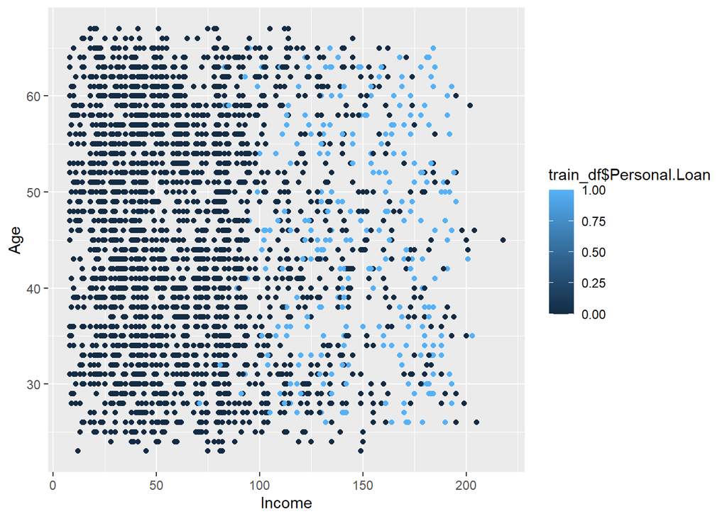

```r
ggplot(train_df, aes(x=Income, y=Age, colour=train_df$Personal.Loan)) + geom_point()
```

This chart shows us that the majority of customers have an income below 100,000 while they are evenly spread between 25 and 65 years old. Moreover, a customer earning more than 100,000 is a lot more to apply for a personal loan.

##Normalization process and k-NN Model

#Normalizing data

A k-NN model is very sensible on the different scales of the variables, so in order to reduce the bias of certain variables on the prediction, we need to normalize the data. For this process, we use preProcess and predict functions from the Caret package. From the initial exploration phase, we know that from the 8th to the 14th column, we only have categorical variables (Education, Securities Account, etc.) that contains only 0 or 1 values. The variable to be predicted (Personal_Loan) is also escluded.

```r
#copy the training and validation sets
norm_train <- train_df
norm_valid <- valid_df

#normalizing data
norm_values <- preProcess(train_df[ , 1:6], method=c("center", "scale"))

#replacing the first 6 columns with the normalized values
norm_train[ , 1:6] <- predict(norm_values, train_df[ , 1:6])
norm_valid[ , 1:6] <- predict(norm_values, valid_df[ , 1:6])
```

```r
#verifying min, median and max values of the normalized data
summary(norm_train)
```

```
##       Age             Experience           Income            Family
##  Min.   :-1.92510   Min.   :-1.99469   Min.   :-1.4351   Min.   :-1.2168
##  1st Qu.:-0.89106   1st Qu.:-0.87296   1st Qu.:-0.7569   1st Qu.:-1.2168
##  Median :-0.02936   Median :-0.01009   Median :-0.2100   Median :-0.3440
##  Mean   : 0.00000   Mean   : 0.00000   Mean   : 0.0000   Mean   : 0.0000
##  3rd Qu.: 0.83233   3rd Qu.: 0.85278   3rd Qu.: 0.5337   3rd Qu.: 0.5289
##  Max.   : 1.86637   Max.   : 1.97452   Max.   : 3.1589   Max.   : 1.4018
##      CCAvg            Mortgage       Personal.Loan    Securities.Account
##  Min.   :-1.1158   Min.   :-0.5467   Min.   :0.0000   Min.   :0.0000
##  1st Qu.:-0.7065   1st Qu.:-0.5467   1st Qu.:0.0000   1st Qu.:0.0000
##  Median :-0.2388   Median :-0.5467   Median :0.0000   Median :0.0000
##  Mean   : 0.0000   Mean   : 0.0000   Mean   :0.0996   Mean   :0.1113
##  3rd Qu.: 0.3458   3rd Qu.: 0.4572   3rd Qu.:0.0000   3rd Qu.:0.0000
##  Max.   : 4.7307   Max.   : 5.6629   Max.   :1.0000   Max.   :1.0000
##    CD.Account          Online         CreditCard      Education_1
##  Min.   :0.00000   Min.   :0.0000   Min.   :0.0000   Min.   :0.0000
##  1st Qu.:0.00000   1st Qu.:0.0000   1st Qu.:0.0000   1st Qu.:0.0000
##  Median :0.00000   Median :1.0000   Median :0.0000   Median :0.0000
##  Mean   :0.06362   Mean   :0.6046   Mean   :0.2971   Mean   :0.4067
##  3rd Qu.:0.00000   3rd Qu.:1.0000   3rd Qu.:1.0000   3rd Qu.:1.0000
##  Max.   :1.00000   Max.   :1.0000   Max.   :1.0000   Max.   :1.0000
##   Education_2      Education_3
##  Min.   :0.0000   Min.   :0.0000
##  1st Qu.:0.0000   1st Qu.:0.0000
##  Median :0.0000   Median :0.0000
##  Mean   :0.2855   Mean   :0.3078
##  3rd Qu.:1.0000   3rd Qu.:1.0000
##  Max.   :1.0000   Max.   :1.0000
```

```r
summary(norm_valid)
```

```
##       Age               Experience            Income
##  Min.   :-1.9250998   Min.   :-1.994693   Min.   :-1.435093
##  1st Qu.:-0.8695198   1st Qu.:-0.872960   1st Qu.:-0.756937
##  Median :-0.0293643   Median :-0.010089   Median :-0.210037
##  Mean   :-0.0005117   Mean   :-0.002661   Mean   : 0.009467
##  3rd Qu.: 0.8323336   3rd Qu.: 0.766495   3rd Qu.: 0.533747
##  Max.   : 1.7802013   Max.   : 1.888228   Max.   : 3.290123
##      Family              CCAvg            Mortgage        Personal.Loan
##  Min.   :-1.216844   Min.   :-1.1158   Min.   :-0.54668   Min.   :0.00000
##  1st Qu.:-1.216844   1st Qu.:-0.7065   1st Qu.:-0.54668   1st Qu.:0.00000
##  Median :-0.343973   Median :-0.2096   Median :-0.54668   Median :0.00000
##  Mean   : 0.005088   Mean   : 0.0431   Mean   : 0.05488   Mean   :0.09059
##  3rd Qu.: 0.528898   3rd Qu.: 0.4043   3rd Qu.: 0.48992   3rd Qu.:0.00000
##  Max.   : 1.401770   Max.   : 4.7307   Max.   : 5.84403   Max.   :1.00000
##  Securities.Account   CD.Account          Online         CreditCard
##  Min.   :0.00000    Min.   :0.00000   Min.   :0.0000   Min.   :0.0000
##  1st Qu.:0.00000    1st Qu.:0.00000   1st Qu.:0.0000   1st Qu.:0.0000
##  Median :0.00000    Median :0.00000   Median :1.0000   Median :0.0000
##  Mean   :0.09409    Mean   :0.05556   Mean   :0.5851   Mean   :0.2893
##  3rd Qu.:0.00000    3rd Qu.:0.00000   3rd Qu.:1.0000   3rd Qu.:1.0000
##  Max.   :1.00000    Max.   :1.00000   Max.   :1.0000   Max.   :1.0000
##   Education_1      Education_2      Education_3
##  Min.   :0.0000   Min.   :0.0000   Min.   :0.0000
##  1st Qu.:0.0000   1st Qu.:0.0000   1st Qu.:0.0000
##  Median :0.0000   Median :0.0000   Median :0.0000
##  Mean   :0.4379   Mean   :0.2733   Mean   :0.2888
##  3rd Qu.:1.0000   3rd Qu.:1.0000   3rd Qu.:1.0000
##  Max.   :1.0000   Max.   :1.0000   Max.   :1.0000
```

#Tranining

Data is now ready to be using in the creation of the k-NN model. We create the training and validation predictors, using all the variables excluding Personal_Loan, and the training and validation labels, using the variable we want the model to predict.

```r
#predictors excluding Personal_Loan
train_predictors <- norm_train[ , -7]
valid_predictors <- norm_valid[ , -7]
#label from Personal_Loan
train_labels <- norm_train[ , 7]
valid_labels <- norm_valid[ , 7]

#k-NN Model with k=1
set.seed(1234)
predicted_labels <- knn(train_predictors, valid_predictors, cl=train_labels, k=1)
```

```r
#viewing the result of the model
head(predicted_labels)
```

```
## [1] 0 0 0 0 0 0
## Levels: 0 1
```

```r
summary(predicted_labels)
```

```
##    0    1
## 1857  141
```

#Confusion Matrix

We can now create a Confusion Matrix and then check the labels from the validation set and the predicted labels for Personal_Loan.

```r
c_matrix <- CrossTable(x=valid_labels, y=predicted_labels, prop.chisq=FALSE)
```

```
##
##
##    Cell Contents
## |-------------------------|
## |                       N |
## |           N / Row Total |
## |           N / Col Total |
## |         N / Table Total |
## |-------------------------|
##
##
## Total Observations in Table:  1998
##
##
##              | predicted_labels
## valid_labels |         0 |         1 | Row Total |
## -------------|-----------|-----------|-----------|
##            0 |      1801 |        16 |      1817 |
##              |     0.991 |     0.009 |     0.909 |
##              |     0.970 |     0.113 |           |
##              |     0.901 |     0.008 |           |
## -------------|-----------|-----------|-----------|
##            1 |        56 |       125 |       181 |
##              |     0.309 |     0.691 |     0.091 |
##              |     0.030 |     0.887 |           |
##              |     0.028 |     0.063 |           |
## -------------|-----------|-----------|-----------|
## Column Total |      1857 |       141 |      1998 |
##              |     0.929 |     0.071 |           |
## -------------|-----------|-----------|-----------|
##
##
```

```r
accuracy <- (c_matrix$t[2,2] + c_matrix$t[1,1])/ sum(c_matrix$t)
print(accuracy)
```

```
## [1] 0.963964
```

```r
recall <- c_matrix$t[2,2]/ (c_matrix$t[2,2] + c_matrix$t[2,1])
print(recall)
```

```
## [1] 0.6906077
```

```r
precision <- c_matrix$t[2,2]/ (c_matrix$t[2,2] + c_matrix$t[1,2])
print(precision)
```

```
## [1] 0.8865248
```

```r
specificity <- c_matrix$t[1,1]/ (c_matrix$t[1,1] + c_matrix$t[1,2])
print(specificity)
```

```
## [1] 0.9911943
```

The model wrongly predicted 72 outcomes. From the Matrix we see the model’s performance: - Accuracy = 96.4% - Sensitivity = 69.1% - Precision = 88.7% - Specificity = 99.1%

##Testing the Model with a new observation

#Add a new customer

```r
new_cust <- data.frame(
  "Age" = as.integer(40),
  "Experience" = as.integer(10),
  "Income" = as.integer(84),
  "Family" = as.integer(2),
  "CCAvg" = as.double(2),
  "Mortgage" = as.integer(0),
  "Personal.Loan" = NA,
  "Securities.Account" = as.factor(0),
  "CD.Account" = as.factor(0),
  "Online" = as.factor(1),
  "CreditCard" = as.factor(1),
  "Education_1" = as.factor(0),
  "Education_2" = as.factor(1),
  "Education_3" = as.factor(0))
head(new_cust)
```

```
##   Age Experience Income Family CCAvg Mortgage Personal.Loan Securities.Account
## 1  40         10     84      2     2        0            NA                  0
##   CD.Account Online CreditCard Education_1 Education_2 Education_3
## 1          0      1          1           0           1           0
```

Of course, we now all of the predictors but we do not know if he would accept the offer of a personal loan. This is why we created the model.

##Partitioning of data into Training, Validation and Test sets

```r
set.seed(1234)
sample2 <- createDataPartition(subset$Income, p=0.80, list=FALSE)
traval_df2 = subset[sample2, ]
test_df2 = subset[-sample2, ]

sample3 = createDataPartition(traval_df2$Income, p=0.50, list=FALSE)
train_df2 = subset[sample3, ]
valid_df2 = subset[-sample3, ]
```

```r
summary(train_df2$Income)
```

```
##    Min. 1st Qu.  Median    Mean 3rd Qu.    Max.
##    8.00   39.00   64.00   74.43   99.00  224.00
```

```r
summary(valid_df2$Income)
```

```
##    Min. 1st Qu.  Median    Mean 3rd Qu.    Max.
##    8.00   39.00   63.00   73.34   97.25  218.00
```

```r
summary(test_df2$Income)
```

```
##    Min. 1st Qu.  Median    Mean 3rd Qu.    Max.
##    8.00   39.00   63.00   73.33   98.00  224.00
```